# DS 2003: Final Project

Xander Johansson

2024-04-23

## The Data

The data for this report was obtained from four main sources on April 17th, 2024:

1. **MLB.com**: The official website of Major League Baseball, [MLB.com](https://www.mlb.com/) offers comprehensive coverage of games, statistics, news, and multimedia content related to professional baseball in the United States. Articles from MLB.com were accessed to fact-check and gather detailed information for the report, including:
   - [4 MVPs on 1 team … how rare is that?](https://www.mlb.com/news/teams-with-the-most-mvps-on-roster-at-same-time)
   - [Dodgers Postseason Results](https://www.mlb.com/dodgers/history/postseason-results)
   - [History of Baseball Around the World](https://www.mlb.com/history/baseball-around-the-world)
   - [Competitive Balance Tax](https://www.mlb.com/glossary/transactions/competitive-balance-tax)
   - [MLB, MLBPA agree to new CBA](https://www.mlb.com/news/mlb-mlbpa-agree-to-cba)
   - [$700M stunner: Ohtani to Dodgers on Biggest Deal in Sports History](https://www.mlb.com/news/shohei-ohtani-contract-with-dodgers)
2. **Baseball Reference**: [Baseball Reference](https://www.baseball-reference.com/) is a comprehensive online database and resource providing historical and statistical information on Major League Baseball. It offers detailed player and team statistics, records, game logs, and analytical tools for fans, researchers, and enthusiasts. Data from Baseball Reference included the Los Angeles Dodgers’ team statistics for every year from 2014-2024, obtained by accessing the team statistics pages and downloading the data in CSV format:
   - [Los Angeles Dodgers’ Team Statistics 2024](https://www.baseball-reference.com/teams/LAD/2024.shtml) (stat14.csv - stat24.csv)
3. **Baseball Cube**: The [Baseball Cube](https://www.thebaseballcube.com/) is an online database specializing in comprehensive statistical information, player profiles, and historical data covering various levels of baseball. This includes Major League Baseball, minor leagues, college baseball, and international leagues. Data from Baseball Cube included the Los Angeles Dodgers’ team payroll and winning percentage for every year from 2014-2023, obtained by navigating the team payroll pages and downloading the data in CSV format:
   - [Los Angeles Dodgers’ Team Payroll 2023](https://www.thebaseballcube.com/content/payroll_year/2023/) (pay2014.csv - pay2023.csv)
4. **Forbes**: [Forbes](https://www.forbes.com/) is a global media company known for its coverage of business, finance, and industry trends. It provides insightful analysis, news, and rankings on various topics. Data from Forbes included the team valuations of every MLB team in 2024. This data was obtained by accessing the MLB Valuations List and requesting the data set via email:
   - [MLB Valuations List](https://www.forbes.com/mlb-valuations/list/) (Revenue24.csv)

## Importing and Cleaning the Data

```r
#import data
for (year in 2014:2023) {  # Loop through the years 2014 to 2023
  # construct the file path for the payroll file of each year
  file_path <- paste0("Data/", year, " Payroll.csv")

  # read the CSV file for the current year
  assign(paste0("pay", year), read_csv(file_path, locale=locale(encoding="latin1")))

  # remove rows with incomplete data
  assign(paste0("pay", year), get(paste0("pay", year))[complete.cases(get(paste0("pay", year))), ])

  # add a column "year" to the dataset
  assign(paste0("pay", year), mutate(get(paste0("pay", year)), year = year))
}

# Convert 'team payroll' column of pay2020, pay2021, and pay2023 to numeric after removing '$' and ',' symbols
pay2020$`team payroll` = as.numeric(gsub("[\\$,]", "", pay2020$`team payroll`))
# pay2021$`team payroll` = as.numeric(gsub("[\\$,]", "", pay2021$`team payroll`))  # Similar operation for pay2021, but commented out
pay2023$`team payroll` = as.numeric(gsub("[\\$,]", "", pay2023$`team payroll`))

# Read the CSV file "Revenue24.csv" and convert 'Value (Billions)' column to numeric after removing '$' and 'B' symbols
Revenue24 <- read_csv("Data/Revenue24.csv")
Revenue24 <- Revenue24 %>%
  mutate(`Value (Billions)` = gsub("\\$|B", "", `Current Value`),  # Remove '$' and 'B'
         `Value (Billions)` = as.numeric(`Value (Billions)`))      # Convert to numeric



#import data, graph 3
for (year in 14:24) {
  # Construct the file path for the file of each year
  file_path <- paste0("Data/stat", year, ".csv")

  # Read the CSV file for the current year
  assign(paste0("stat", year), read.csv(file_path, encoding = "latin1"))

  # Remove rows with incomplete data
  assign(paste0("stat", year), get(paste0("stat", year))[complete.cases(get(paste0("stat", year))), ])

  # Add a column "year" to the dataset
  assign(paste0("stat", year), transform(get(paste0("stat", year)), year = year))
}


for (year in 2014:2023) {
  # Get the dataset for the current year
  data <- get(paste0("pay", year))

  # Create a new column "Payroll Rank" with ranks in descending order of "team payroll"
  data <- mutate(data, Payroll_Rank = rank(-`team payroll`, ties.method = "min"))

  # Assign the modified dataset back to the environment
  assign(paste0("pay", year), data)
}


# Combine pay datasets from multiple years into one dataset
combined_pay_data <- bind_rows(pay2023, pay2022, pay2021, pay2020, pay2019, pay2018, pay2017, pay2016, pay2015, pay2014)

# Trim leading and trailing whitespace from column names
colnames(combined_pay_data) <- trimws(colnames(combined_pay_data))

# Replace special characters in column names with appropriate characters
combined_pay_data[combined_pay_data$year == "2023", ]$`  w` = combined_pay_data[combined_pay_data$year == "2023",]$`Â Â w`
combined_pay_data[combined_pay_data$year == "2023", ]$`  l` = combined_pay_data[combined_pay_data$year == "2023",]$`Â Â l`

# Remove columns containing special characters from the dataset
combined_pay_data <- subset(combined_pay_data, select = -c(`Â Â l`, `Â Â w`))

# Select specific columns from the dataset and rename them
combined_pay_data <- combined_pay_data %>%
  select(`team name`, roster, league, division, `team payroll`, `  w`, `  l`, wpct,
         rank, lgrk, `mlb rk`, `last yr payroll`, `top salary`, year, Payroll_Rank)

# Remove non-alphabetic characters from column names
colnames(combined_pay_data) <- gsub("[^a-zA-Z]", "", colnames(combined_pay_data))
# str(combined_pay_data)


# Filter combined_pay_data to create a dataset containing only Los Angeles Dodgers
dodgers <- combined_pay_data[combined_pay_data$teamname == "Los Angeles Dodgers",]

# Filter combined_pay_data to create a dataset containing only Oakland Athletics
athletics <- combined_pay_data[combined_pay_data$teamname == "Oakland Athletics",]

# Create a copy of combined_pay_data named pay_data
pay_data <- combined_pay_data

# Filter pay_data to remove rows where teamname is either Los Angeles Dodgers or Oakland Athletics
pay_data <- combined_pay_data[combined_pay_data$teamname != "Los Angeles Dodgers"
                              & combined_pay_data$teamname != "Oakland Athletics",]

# Calculate the yearly difference in winning percentage (wpct) within combined_pay_data
yearly_difference <- combined_pay_data %>%
  group_by(year) %>%
  summarize(difference = max(wpct) - min(wpct))


# Calculate the median value of "Value (Billions)" column in Revenue24 dataset
median_value_2024 <- median(Revenue24$`Value (Billions)`)

# Create vectors of team names for top 50% and bottom 50% based on "Value (Billions)" in Revenue24 dataset
top_teams <- Revenue24$Team[Revenue24$`Value (Billions)` >= median_value_2024]
bottom_teams <- Revenue24$Team[Revenue24$`Value (Billions)` < median_value_2024]

# Create a new column Color_Category in pay_data based on teamname membership in top_teams or bottom_teams
pay_data <- pay_data %>%
  mutate(Color_Category = ifelse(teamname %in% top_teams, "Top 50%", "Bottom 50%"))

# Combine the stat datasets for the years 2014 to 2024 into a single dataset
stats <- bind_rows(stat14, stat15, stat16, stat17, stat18, stat19, stat20, stat21, stat22, stat23, stat24)

# Add 2000 to the "year" column in stats dataset to align with the years in the combined_pay_data dataset
stats$year = stats$year + 2000


# Filter rows in stats dataset where the player name is "Freddie Freeman", "Mookie Betts", or "Shohei Ohtani"
trio <- stats[stats$Name == "Freddie Freeman" | stats$Name == "Mookie Betts" | stats$Name == "Shohei Ohtani", ]

# Filter rows in stats dataset where the player name is not "Freddie Freeman", "Mookie Betts", or "Shohei Ohtani"
dodgers2 <- stats[stats$Name != "Freddie Freeman" & stats$Name != "Mookie Betts" & stats$Name != "Shohei Ohtani", ]

# Calculate the total wins above replacement (WAR) for each year in the stats dataset
war_sum <- stats %>%
  group_by(year) %>%
  summarize(total_war = sum(WAR, na.rm = TRUE))

# Calculate the total WAR for "Freddie Freeman", "Mookie Betts", and "Shohei Ohtani" for each year
war_sum1 <- trio %>%
  group_by(year) %>%
  summarize(total_war = sum(WAR, na.rm = TRUE))

# Calculate the total WAR for players other than "Freddie Freeman", "Mookie Betts", and "Shohei Ohtani" for each year
war_sum2 <- dodgers2 %>%
  group_by(year) %>%
  summarize(total_war = sum(WAR, na.rm = TRUE))

# Combine the calculated WAR sums for trio and dodgers2, and assign a source column to identify each group
combined_war <- bind_rows(
  mutate(war_sum1, source = "trio"),
  mutate(war_sum2, source = "dodgers")
)


# Reorder levels of the source variable to ensure consistent plotting
combined_war$source <- factor(combined_war$source, levels = c('trio', 'dodgers'))

# Pivot the combined war data to have years as columns and total war as values
combined_war_pivoted <- combined_war %>%
  pivot_wider(names_from = year,
              values_from = total_war)

# Replace any missing values with 0
combined_war_pivoted <- combined_war_pivoted %>%
  mutate_all(~ ifelse(is.na(.), 0, .))

# Extract the total WAR values for the trio (first row)
trio_values <- combined_war_pivoted[1, -1]

# Extract the total WAR values for the dodgers (second row)
dodgers_values <- combined_war_pivoted[2, -1]

# Perform element-wise division to calculate the percentage of trio WAR out of total WAR
percentage_trio_war <- trio_values / (trio_values + dodgers_values)

# Filter the combined war data for years starting from 2020
combined_war <- combined_war %>%
  filter(year >= 2020)

# Calculate the average WAR for dodgers excluding the year 2024
average_dodgers_war <- mean(dodgers$WAR[dodgers$year != 2024], na.rm = TRUE)

# Calculate the average WAR for trio excluding the year 2024
average_trio_war <- mean(trio$WAR[trio$year != 2024], na.rm = TRUE)
```

## Baseball and Major League Baseball

### A. The Game of Baseball

Baseball, often referred to as “America’s pastime,” is a sport deeply ingrained in the cultural fabric of the United States. Originating in the 18th century and evolving over time, baseball has become one of the most popular and widely followed sports in the country.

### B. Major League Baseball (MLB)

Major League Baseball (MLB) is the premier professional baseball league in the world, consisting of 30 teams divided into two leagues: the National League (NL) and the American League (AL). Each league is further divided into three divisions: East, Central, and West.

MLB teams represent various cities across the United States and Canada, with franchises deeply embedded in their respective communities. From storied franchises like the New York Yankees and Boston Red Sox to newer additions like the Tampa Bay Rays and Arizona Diamondbacks, each team brings its unique history and fan base to the league.

The MLB operates under a Collective Bargaining Agreement (CBA) negotiated between the league’s owners and the MLB Players Association (MLBPA). The CBA governs various aspects of player contracts, free agency, revenue sharing, and other key components of the league’s operations. It serves as the foundation for the financial and competitive structure of MLB.

### C. Financial Dynamics in MLB

Unlike many other major professional sports leagues, such as the NFL and NBA, MLB does not enforce a strict salary cap limiting teams’ expenditures on player salaries. This absence of a salary cap allows teams to spend as much as they desire on player contracts, subject to certain financial constraints and penalties.

Instead of a salary cap, MLB operates under a Luxury Tax system, also known as the Competitive Balance Tax (CBT). The Luxury Tax imposes penalties on teams whose payrolls exceed a predetermined threshold set by the league. Teams exceeding the threshold are required to pay a tax on the amount by which they exceed the limit, with the severity of the tax increasing for repeat offenders.

### D. Competitive Balance and League Parity

While MLB strives for competitive balance among its teams, the absence of a salary cap and the presence of revenue disparities between franchises pose challenges to achieving true parity. Wealthier teams with larger market sizes and higher revenues often have a significant financial advantage over smaller-market teams with more limited resources.

The competitive landscape of MLB is shaped by the financial disparities between teams, with wealthier franchises often dominating the league in terms of talent acquisition and on-field success. This dynamic raises questions about the efficacy of existing mechanisms, such as revenue sharing and the Luxury Tax, in fostering competitive balance and ensuring the integrity of the league.

## A Tale of Two Teams: The Los Angeles Dodgers and the Oakland Athletics

A notable disparity between two prominent teams in the MLB, the Los Angeles Dodgers and the Oakland Athletics, unveils these dynamics of competition and resource allocation within baseball. The Dodgers, epitomizing a model of sustained success, have emerged as a formidable force propelled by considerable financial investment. Bolstered by the acquisition of star athletes such as Mookie Betts, Freddie Freeman, and Shohei Ohtani, the Dodgers have solidified their position as perennial contenders, consistently dominating the MLB regular season.

In stark contrast, the Oakland Athletics, although possessing a rich historical legacy and dedicated fan base, grapple with inherent challenges stemming from limited financial resources. Despite sporadic achievements, the Athletics find themselves in a perpetual struggle against resource constraints and the widening gap in financial capabilities.

### The Los Angeles Dodgers: A Dynasty in the Making

The Los Angeles Dodgers are one of the most prominent and historically successful franchises in Major League Baseball. They are also the second most valuable in the sport, behind only the New York Yankees. Based in Los Angeles, California, the Dodgers have established themselves as perennial contenders, boasting a rich history of championships and iconic players.

The Dodgers spare no expense in their pursuit of excellence on the field. They allocate substantial funds to secure the services of elite players, both through free agency and trades, ensuring that they assemble a roster capable of competing at the highest level.

The graph below illustrates the Dodgers’ consistent investment in their on-field product:

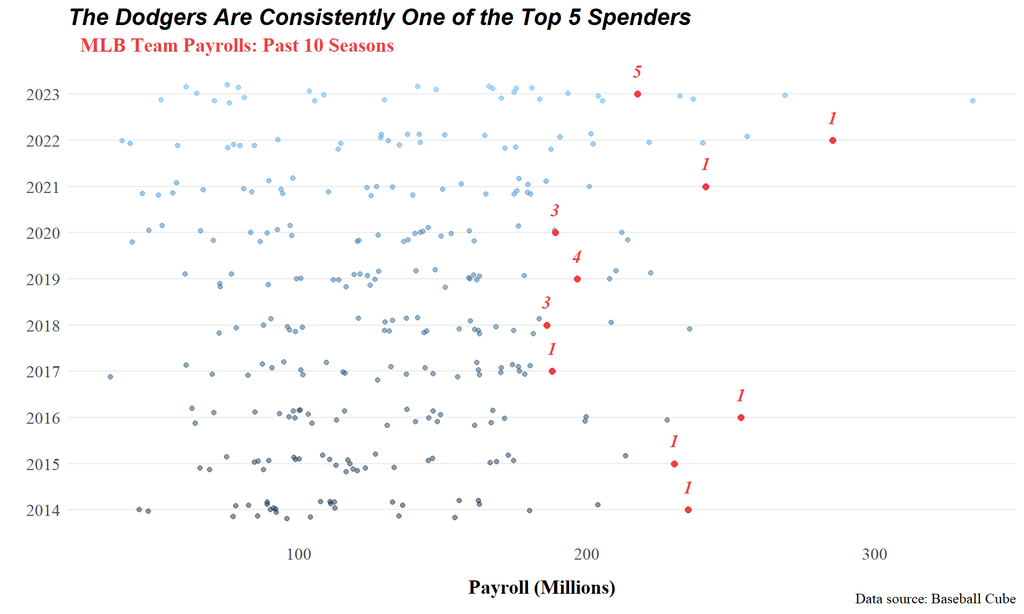

```r
# Create a ggplot object with pay_data as the data and specify aesthetics
ggplot(pay_data, aes(x = teampayroll / 1000000, y = year, color = year)) +
  # Add jitter to the scatter plot for better visualization
  geom_point(position = position_jitter(width = .1, height = .2), alpha = .5) +
  # Highlight the Dodgers' payroll with a different color and size
  geom_point(data = dodgers, color = "#EF3E42", size = 2) +
  # Add labels and titles to the plot
  labs(x = "Payroll (Millions)", y = "",
       subtitle = "MLB Team Payrolls: Past 10 Seasons",
       title = "The Dodgers Are Consistently One of the Top 5 Spenders",
       caption = "Data source: Baseball Cube") +
  # Set breaks for the y-axis
  scale_y_continuous(breaks = unique(combined_pay_data$year)) +
  # Change theme to minimal
  theme_minimal() +
  # Add labels for the Dodgers' payroll rank
  geom_text(data = dodgers, aes(label = PayrollRank), fontface = "bold.italic", color = "#EF3E42", size = 4.5, vjust = -1.3, family = "serif") +
  # Format title, subtitle, and axis titles
  theme(plot.title = element_text(size = 16, face = "bold.italic"),
        plot.subtitle = element_text(size = 14, face = "bold", color = "#EF3E42", hjust = 0.02, family = "serif"),
        axis.title.x = element_text(size = 14, family = "serif", face = "bold", vjust = -2),
        plot.caption = element_text(size = 10, family = "serif"),
        axis.text.x = element_text(size = 12, family = "serif"),
        axis.text.y = element_text(size = 12, family = "serif"),
        panel.grid.minor.y = element_blank(),
        panel.grid.minor.x = element_blank(),
        panel.grid.major.x = element_blank()
        ) +
  # Remove the legend
  guides(color = FALSE)
```

Over the past decade, the Los Angeles Dodgers have consistently ranked among the top five teams in terms of payroll expenditure, a testament to their financial resources and unwavering commitment to fielding a competitive team year after year.

During this period, the Dodgers have asserted their dominance with an impressive nine NL West Division titles, in addition to clinching three NL pennants and a World Series championship. These remarkable achievements not only underscore the Dodgers’ supremacy within their division but also highlight their stature as a powerhouse in the league.

In Major League Baseball, player payroll expenditure transcends mere financial transactions; it profoundly influences a team’s competitiveness, success, and overall financial health. The Dodgers exemplify the significance of financial resources in shaping a team’s trajectory, utilizing their substantial financial backing to secure top-tier talent and maintain their winning tradition.

### The Oakland Athletics: Struggling with Financial Constraints

The Oakland Athletics, like the Los Angeles Dodgers, hold a significant place in Major League Baseball history. Founded in Philadelphia in 1901 before moving to Kansas City and finally settling in Oakland, California, the Athletics have a storied past characterized by periods of success and innovation.

With a total of nine World Series championships to their name, the Athletics have produced legendary players and memorable moments throughout their history. However, in recent years, they have struggled to achieve the same level of success as some of their counterparts, including the Dodgers.

Challenges stemming from limited financial resources have hindered the Athletics’ ability to assemble and maintain a competitive roster capable of contending for championships. The Athletics generated the lowest revenue in 2024 of any team in the MLB and are the second to least valuable team overall. This disparity in financial capabilities between teams like the Dodgers and the Athletics underscores the profound impact of financial resources on a team’s ability to compete effectively in MLB.

Comparing the Dodgers to the Athletics and other teams across the league provides valuable insights into how financial dynamics shape the competitive landscape of Major League Baseball.

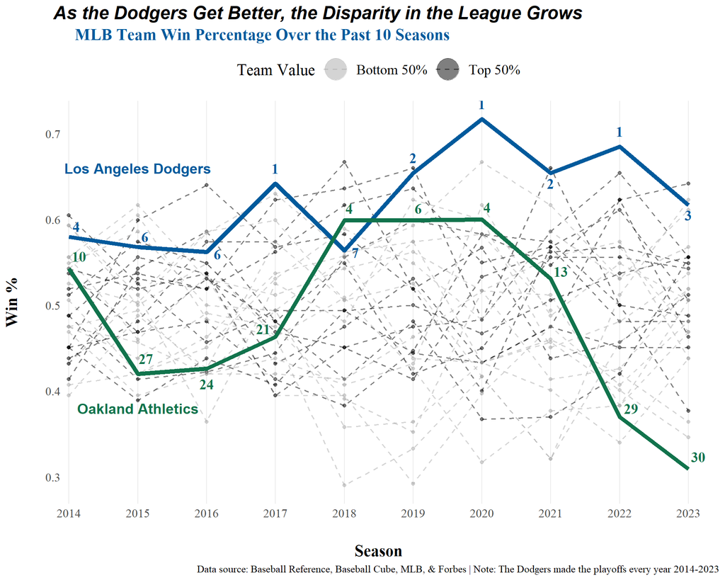

```r
# Create a ggplot object with pay_data as the data and specify aesthetics
ggplot(pay_data, aes(x = year, y = wpct, group = teamname, color = Color_Category)) +
  # Add a dashed line plot with transparency and smaller size
  geom_line(alpha = .5, size = .6, linetype = "dashed") +
  # Manually set colors for the color scale
  scale_color_manual(values = c("darkgray", "black"))+
  # Add points to the plot with size and transparency
  geom_point(size = 1.5, alpha = .5) +
  # Add a solid line plot for Dodgers' data with a specific color and size
  geom_line(data = dodgers, aes(x = year, y = wpct), color = "#005A9C", size = 2) +
  # Add a solid line plot for Athletics' data with a specific color and size
  geom_line(data = athletics, aes(x = year, y = wpct), color = "#11734C", size = 2) +
  # Add text labels for Dodgers' data with filters for specific years
  geom_text(data = filter(dodgers, year != 2014 & year != 2015 & year != 2016 & year != 2018 & year != 2021 & year != 2023), aes(x = year, y = wpct, label = mlbrk), color = "#005A9C", vjust = -1, family = "serif", fontface = "bold", size = 5) +
  # Add text labels for Dodgers' data with filters for specific years
  geom_text(data = filter(dodgers, year == 2014 | year == 2015), aes(x = year, y = wpct, label = mlbrk), color = "#005A9C", vjust = -.5, hjust = -.5, family = "serif", fontface = "bold", size = 5) +
  # Add text labels for Dodgers' data with filters for specific years
  geom_text(data = filter(dodgers, year == 2016 | year == 2018), aes(x = year, y = wpct, label = mlbrk), color = "#005A9C", vjust = .7, hjust = -1, family = "serif", fontface = "bold", size = 5) +
  # Add text labels for Dodgers' data with filters for specific years
  geom_text(data = filter(dodgers, year == 2021 | year == 2023), aes(x = year, y = wpct, label = mlbrk), color = "#005A9C", vjust = 1.5, family = "serif", fontface = "bold", size = 5) +
  # Add text labels for Athletics' data with filters for specific years
  geom_text(data = filter(athletics, year != 2017 & year != 2022 & year != 2015 & year != 2016 & year != 2021),
            aes(x = year, y = wpct, label = mlbrk), color = "#11734C", vjust = -.7, hjust = -.2, family = "serif", fontface = "bold", size = 5) +
  # Add text labels for Athletics' data with filters for specific years
  geom_text(data = filter(athletics, year == 2015), aes(x = year, y = wpct, label = mlbrk),
            color = "#11734C", vjust = -1, hjust = -.05, family = "serif", fontface = "bold", size = 5) +
  # Add text labels for Athletics' data with filters for specific years
  geom_text(data = filter(athletics,year == 2022), aes(x = year, y = wpct, label = mlbrk),
            color = "#11734C", vjust = -.3, hjust = -.3, family = "serif", fontface = "bold", size = 5) +
  # Add text labels for Athletics' data with filters for specific years
  geom_text(data = filter(athletics, year == 2017), aes(x = year, y = wpct, label = mlbrk), color = "#11734C", vjust = -.3, hjust = 1.35, family = "serif", fontface = "bold", size = 5) +
  # Add text labels for Athletics' data with filters for specific years
  geom_text(data = athletics %>% filter(year == 2021),
            aes(x = year, y = wpct, label = mlbrk), color = "#11734C", vjust = -.2, hjust = -.2, family = "serif", fontface = "bold", size = 5) +
  # Add text labels for Athletics' data with filters for specific years
  geom_text(data = athletics %>% filter(year == 2016),
            aes(x = year, y = wpct, label = mlbrk), color = "#11734C", vjust = 2, family = "serif", fontface = "bold", size = 5) +
  # Add labels and titles to the plot
  labs(x = "Season", y = "Win %",
       subtitle = "MLB Team Win Percentage Over the Past 10 Seasons",
       title = "As the Dodgers Get Better, the Disparity in the League Grows",
       caption = "Data source: Baseball Reference, Baseball Cube, MLB, & Forbes | Note: The Dodgers made the playoffs every year 2014-2023") +
  # Set breaks for the x-axis
  scale_x_continuous(breaks = unique(pay_data$year)) +
  # Change theme to minimal
  theme_minimal() +
  # Format title, subtitle, and axis titles
  theme(plot.title = element_text(size = 18, face = "bold.italic", hjust = .1),
        plot.subtitle = element_text(size = 16, face = "bold", color = "#005A9C", hjust = 0.12, family = "serif"),
        plot.caption = element_text(size = 10, family = "serif"),
        axis.title.x = element_text(size = 16, family = "serif", face = "bold", margin = margin(t = 25)),
        axis.title.y = element_text(size = 16, family = "serif", face = "bold", margin = margin(r = 25)),
        axis.text.x = element_text(size = 12, family = "serif"),
        axis.text.y = element_text(size = 12, family = "serif", margin = margin(r = -25)),
        panel.grid.minor.y = element_blank(),
        panel.grid.minor.x = element_blank(),
        panel.grid.major.y = element_blank(),
        legend.text = element_text(size = 14, family = "serif"),
        legend.title = element_text(size = 16, family = "serif")
  ) +
  # Add a legend for the color scale
  guides(color = guide_legend(title = "Team Value", position = "top", override.aes = list(size=10))) +
  # Annotate Dodgers and Athletics text labels
  annotate("text", x = 2015, y = 0.66, label = "Los Angeles Dodgers", color = "#005A9C", fontface = "bold", size = 5) +
  annotate("text", x = 2015, y = 0.38, label = "Oakland Athletics", color = "#11734C", fontface = "bold", size = 5)
```

Two historically successful teams are in very different positions now. The stark contrast between the trajectories of the Los Angeles Dodgers and the Oakland Athletics serves as a powerful illustration of the pronounced disparity inherent in Major League Baseball, shedding light on the intricate dynamics of competition and resource allocation within the league. In the early years, although there were variations in overall rankings, the Athletics consistently trailed the Dodgers in terms of winning percentage. Despite experiencing fleeting success with top-10 finishes from 2018 to 2020, the Athletics faced an anticipated downturn, culminating in finishes of 29th and 30th in 2022 and 2023, respectively. Despite maintaining similar rankings to those in 2015 and 2016, this decline underscores the widening gap, as their winning percentage dropped below 40%.

Looking beyond the Dodgers and Athletics, the disparity becomes even more apparent when examining teams based on their value. Sustained success predominantly favors wealthier teams like the Dodgers. While lower-value teams may occasionally excel, they struggle to maintain competitiveness over time. Financial disparities exacerbate this situation, with wealthier teams leveraging their resources to secure top talent, coaching, and front office staff. This trend is unmistakably reflected in the league, as illustrated in the accompanying graph. Initially, in 2014, the range of winning percentages was relatively narrow, suggesting a more evenly matched field. However, as the years progressed, the spread widened significantly, highlighting the growing gap between teams with varying financial resources. As these financial gaps widen, teams face increasingly daunting challenges in remaining competitive.

This disparity is further compounded by the direct correlation between on-field success and increased revenue streams for MLB teams. Winning teams attract larger crowds to stadiums, command higher ticket prices, and generate more revenue from merchandise sales and sponsorship deals. Consequently, teams with higher payrolls often experience a boost in their overall revenue and team valuations. The consistent spending by teams like the Dodgers at the top of the financial spectrum creates a significant gap in resources among MLB teams. This disparity exacerbates the division between the league’s financially affluent franchises and those with more limited resources, making it increasingly challenging for smaller-market teams to compete on an equal footing.

## The Dodgers’ Investments: Building A Dynasty

The Dodgers’ financial prowess transcends player salaries, extending to investments in coaching, accommodations, and facilities. This comprehensive approach not only elevates the team’s performance but also positions them as an attractive destination for players seeking both competitive success and luxurious working conditions. The allure of joining the Dodgers is such that players may even be willing to accept pay cuts, further widening the competitive advantage enjoyed by financially robust franchises. This trend, coupled with the Dodgers’ relentless pursuit of success, is exemplified by their recent acquisitions.

Despite already boasting an impressive lineup of All-MLB players, All-Stars, playoff MVPs, Silver Sluggers, and Golden Glove winners, the Dodgers continue to augment their roster. In 2020, they secured Mookie Betts from the Boston Red Sox, a former MVP and perennial All-Star known for his exceptional athleticism and all-around skills. His defensive prowess and offensive capabilities make him a cornerstone player for any team. Then in 2022, the Dodgers added another player that lead the Atlanta Braves to a World Series Championships the season before. Another former MVP, All-Star, Golden Glover, and Silver Slugger to their lineup in Freddie Freeman.

However, it was their acquisition of Shohei Ohtani in 2024 that truly made waves. Ohtani, renowned as one of the best players in the league and a rare two-way player, entered free agency with immense anticipation. His signing with the Dodgers for $700 million over 10 years marked the largest contract in sports history.

In 2024, this trio have constituted 54% of the team’s bWAR so far.

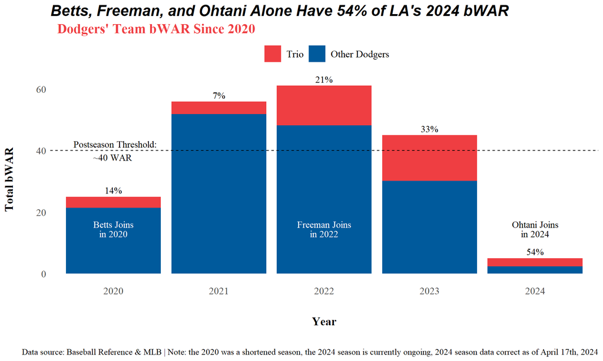

```r
# Plot the stacked bar chart with percentage labels
ggplot(combined_war, aes(x = factor(year), y = total_war, fill = source)) +
  # Add stacked bar chart
  geom_bar(stat = "identity") +
  # Add percentage labels for "trio" source
  geom_text(aes(label = ifelse(source == "trio", paste0(round(percentage_trio_war * 100), "%"), "")),
            position = position_stack(1),
            vjust = -.5, color = "black", size = 4,
            family = "serif") +
  # Add threshold line
  geom_hline(yintercept = 40, linetype = "dashed", color = "black") +
  # Add labels and titles
  labs(x = "Year", y = "Total bWAR",
       subtitle = "Dodgers' Team bWAR Since 2020",
       title = "Betts, Freeman, and Ohtani Alone Have 54% of LA's 2024 bWAR",
       caption = "Data source: Baseball Reference & MLB | Note: the 2020 was a shortened season, the 2024 season is currently ongoing, 2024 season data correct as of April 17th, 2024") +
  # Apply minimal theme
  theme_minimal() +
  # Format title, subtitle, and axis titles
  theme(plot.title = element_text(size = 18, face = "bold.italic"),
        plot.subtitle = element_text(size = 16, face = "bold", color = "#EF3E42", hjust = 0.02, family = "serif"),
        axis.title.x = element_text(size = 14, family = "serif", face = "bold", margin = margin(t = 25)),
        axis.title.y = element_text(size = 14, family = "serif", face = "bold", margin = margin(r = 25)),
        plot.caption = element_text(size = 10, family = "serif", margin = margin(t = 25)),
        axis.text.x = element_text(size = 12, family = "serif"),
        axis.text.y = element_text(size = 12, family = "serif"),
        panel.grid.minor.y = element_blank(),
        panel.grid.minor.x = element_blank(),
        panel.grid.major.y = element_blank(),
        panel.grid.major.x = element_blank(),
        legend.text = element_text(size = 12, family = "serif")
        ) +
  # Set colors and legend labels
  scale_fill_manual(values = c("trio" = "#EF3E42", "dodgers" = "#005A9C"),
                    labels = c("trio" = "Trio", "dodgers" = "Other Dodgers")) +
  # Add legend for the color scale
  guides(fill = guide_legend(title = "", position = "top", override.aes = list(size=7))) +
  # Add annotation text
  annotate("text", x = .7, y = 40, label = "Postseason Threshold:",
           size = 4, family = "serif", vjust = -.5, hjust = .1, color = "black") +
  annotate("text", x = .7, y = 40, label = "~40 WAR",
           size = 4, family = "serif", vjust = 1.5, hjust = -.3, color = "black") +
  annotate("text", x = 1, y = 15, label = "Betts Joins",
           size = 4, family = "serif", vjust = 0, color = "white") +
  annotate("text", x = 1, y = 13, label = "in 2020",
           size = 4, family = "serif", color = "white") +
  annotate("text", x = 3, y = 15, label = "Freeman Joins",
           size = 4, family = "serif", vjust = 0, color = "white") +
  annotate("text", x = 3, y = 13, label = "in 2022",
           size = 4, family = "serif", color = "white") +
  annotate("text", x = 5, y = 15, label = "Ohtani Joins",
           size = 4, family = "serif", vjust = 0, color = "black") +
  annotate("text", x = 5, y = 13, label = "in 2024",
           size = 4, family = "serif", color = "black")
```

### Shohei Ohtani as a Reflection of Spending Disparity

The acquisition of Shohei Ohtani by the Dodgers this past offseason exemplifies the profound impact of spending disparity in Major League Baseball. Despite the Dodgers’ already substantial payroll, their ability to secure Ohtani’s services with Betts and Freeman demonstrates their capacity to attract and retain elite talent, further solidifying their position as perennial contenders.

Moreover, the signing of Ohtani not only enhances the Dodgers’ on-field capabilities but also carries significant financial implications. The influx of a player of Ohtani’s caliber can drive increased revenue through heightened fan engagement, ticket sales, merchandise, and sponsorship deals, bolstering the Dodgers’ overall financial standing and team valuations.

The manner in which the Dodgers structured Ohtani’s contract highlights the creative financial maneuvering facilitated by their resources. Faced with the challenge of accommodating Ohtani’s fair compensation within their existing payroll expenditure, the Dodgers exploited a loophole in the competitive bargaining agreement to defer a significant portion of Ohtani’s salary to the end of his contract.

While Ohtani will still benefit from lucrative endorsements, the deferred salary arrangement effectively diminishes his annual earnings to a fraction of his market value. The Dodgers’ ability to secure such a deal underscores the widening disparity in financial resources across MLB teams. Such advantageous financial arrangements further solidify the competitive advantage enjoyed by financially robust franchises like the Dodgers, exacerbating the divide between teams with ample resources and those with more limited financial means.

Ohtani’s acquisition by the Dodgers exemplifies a deal that would be unattainable for lesser-funded teams such as the Athletics. The financial resources and flexibility required to negotiate and execute such agreements are beyond the reach of teams with more constrained budgets, perpetuating the cycle of spending disparity in MLB.

In the 2024 season, Betts, Freeman, and Ohtani are poised to contend for the NL MVP award, further solidifying the Dodgers’ dominance in the league. The presence of three MVP-caliber players underscores the unparalleled depth and talent of the Dodgers’ roster.

Furthermore, the 2024 Dodgers are only the 6th team in history with 4 MVPs on its roster, joining the list of the 2022 Dodgers, 2021 Dodgers, 1996 Red Sox, 1982 Angels, and the 1978 Reds. Such a rare achievement speaks volumes about the Dodgers’ dominance, as the franchise owns half of these 6 instances, all occurring within the past 5 seasons. This achievement stands in stark contrast to the Oakland Athletics, whose starting lineup would likely only crack the Dodgers’ Triple-A team.

## Addressing Disparity in the MLB

The Dodgers’ acquisition of top-tier talent, including players like Mookie Betts, Freddie Freeman, and Shohei Ohtani is unprecedented. This concentration of talent within a single franchise not only solidifies the Dodgers’ dominance but also exacerbates the competitive disparity across the MLB.

Moreover, the Dodgers’ strategic maneuvers, such as recruiting talent from other teams and exploiting loopholes in the Collective Bargaining Agreement, further accentuate their advantage. Their substantial financial resources afford them the capability to outbid competitors and secure coveted players, perpetuating their stronghold on the league.

As Major League Baseball continues to witness the widening chasm between financially robust franchises like the Los Angeles Dodgers and their less affluent counterparts, the specter of a sport dominated by a select few looms ominously. Left unchecked, this trend risks undermining the essence of baseball as a sport for all, jeopardizing its appeal to fans.

Given the considerable influence wielded by wealthier teams, a critical question emerges: Does MLB need to establish new regulations to foster greater parity within the league? One potential solution is the implementation of a salary cap, akin to those enforced in other major sports leagues in the United States.

A salary cap would impose a predetermined limit on the total amount a team can spend on player salaries, thereby leveling the playing field and mitigating the advantage enjoyed by wealthier franchises. By instituting financial constraints, the league can promote fair competition, prevent teams from monopolizing talent, and enhance the overall competitiveness of MLB.

The implementation of a salary cap in MLB would entail various challenges and considerations. The league would need to navigate negotiations with players’ unions, address concerns regarding revenue sharing and competitive balance, and establish mechanisms for enforcement and compliance. Yet, the challenge is worth it. The adoption of a salary cap has the potential to yield significant benefits for MLB. Beyond promoting competitive balance, it could enhance fan engagement, stimulate interest in smaller-market teams, and safeguard the integrity of the sport. Moreover, by fostering a more equitable environment, MLB can ensure the sustainability and longevity of baseball as a premier professional sport.